# PA1_template.Rmd

Bas Korevaar

Monday, August 10, 2015

## Load various libraries to be used in this work:

```r
library(ggplot2)
library(dplyr)
```

## Loading and preprocessing the data

1. Load the data (i.e. read.csv())
2. Process/transform the data (if necessary) into a format suitable for your analysis

```r
dataset=NULL
  dataset <- read.csv("activity.csv", header=TRUE, stringsAsFactors=FALSE)
  cleandata <- na.omit(dataset)
```

## What is mean total number of steps taken per day?

1. Calculate the total number of steps taken per day
2. Make a histogram of the total number of steps taken each day
3. Calculate and report the mean and median of the total number of steps taken per day

```
## stat_bin: binwidth defaulted to range/30. Use 'binwidth = x' to adjust this.
```

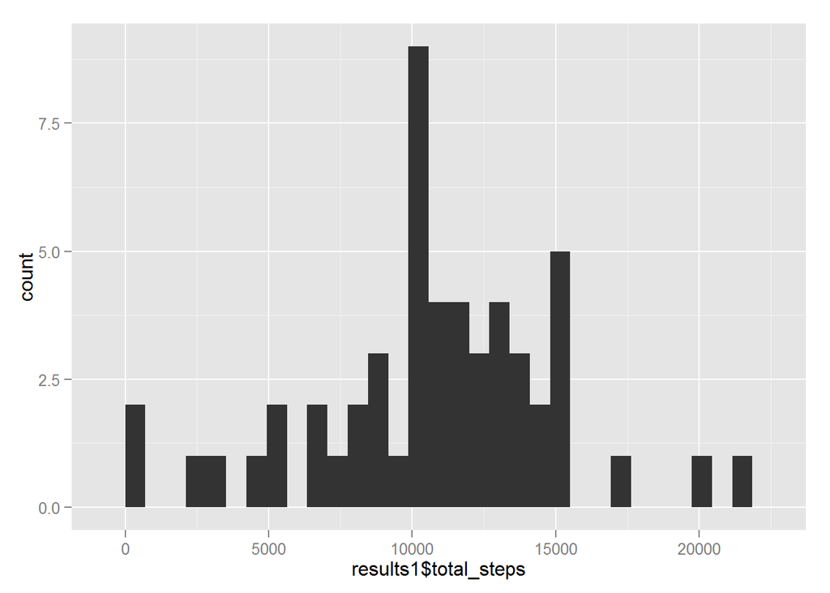

```r
## There are 61 unique days in the data
## After removing NA, 53 unique days are left
total_steps=sum(cleandata$steps)
results1=cleandata %>%
   group_by(date) %>%
   summarize(total_steps=sum(steps))

qplot(results1$total_steps, geom="histogram")
```

### Data Summary:

- The mean number of steps taken per day: 10766
- The median number of steps taken per day: 10765

## What is the average daily activity pattern?

1. Make a time series plot (i.e. type = “l”) of the 5-minute interval (x-axis) and the average number of steps taken, averaged across all days (y-axis)
2. Which 5-minute interval, on average across all the days in the dataset, contains the maximum number of steps?

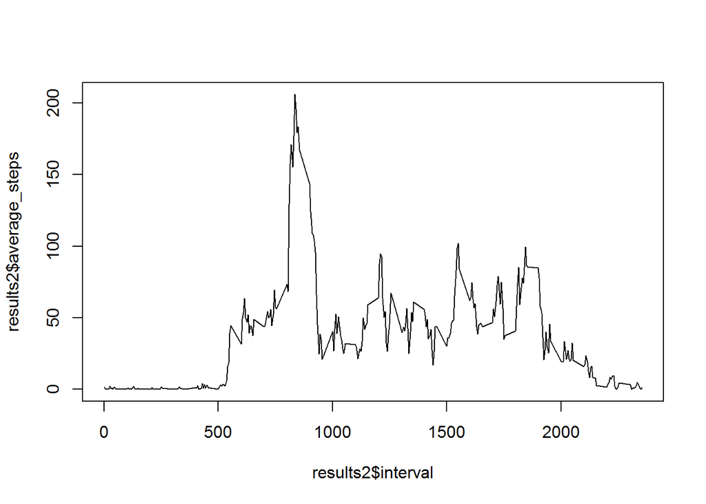

```r
results2=cleandata %>%
   group_by(interval) %>%
   summarize(average_steps=mean(steps))
plot(results2$interval,results2$average_steps,type="l")
```

```r
max_steps=max(results2$average_steps)
```

### Data Summary:

- The 5-minute interval in which, on average, the most steps are taken is interval 835, with an average of 206 steps.

## Inputting missing values

1. Calculate and report the total number of missing values in the dataset (i.e. the total number of rows with NAs)
2. Devise a strategy for filling in all of the missing values in the dataset. The strategy does not need to be sophisticated. For example, you could use the mean/median for that day, or the mean for that 5-minute interval, etc.
3. Create a new dataset that is equal to the original dataset but with the missing data filled in.
4. Make a histogram of the total number of steps taken each day and Calculate and report the mean and median total number of steps taken per day. Do these values differ from the estimates from the first part of the assignment? What is the impact of imputing missing data on the estimates of the total daily number of steps?

```
## stat_bin: binwidth defaulted to range/30. Use 'binwidth = x' to adjust this.
```

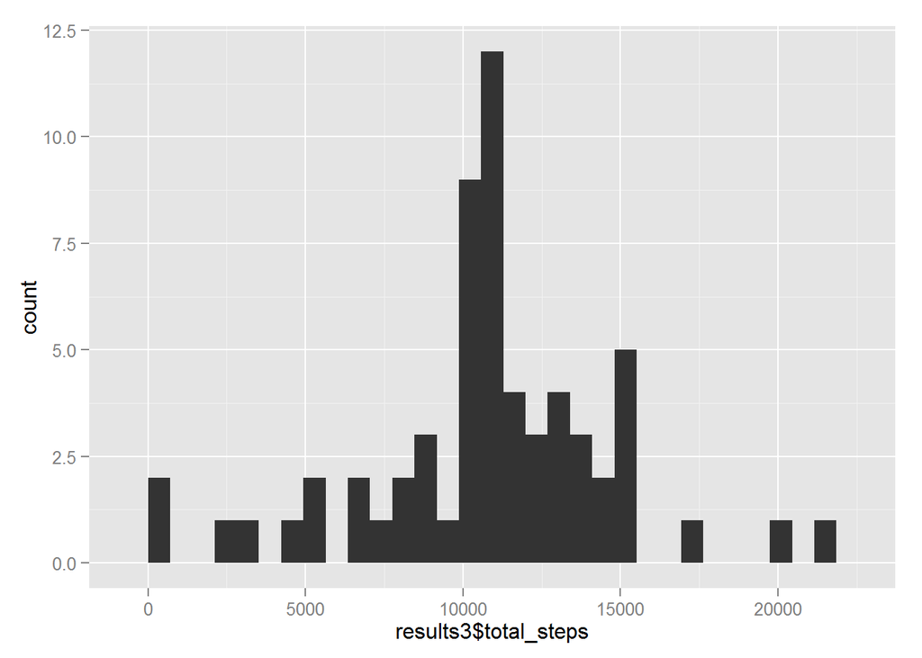

```r
results3=dataset %>%
   group_by(date) %>%
   summarize(total_steps=sum(steps))
results3[is.na(results3)]<-median(results1$total_steps)

qplot(results3$total_steps, geom="histogram")
```

### Data Summary:

- The total number of rows with missing data is 2304 rows.
- The mean number of steps taken per day: 10766
- The median number of steps taken per day: 10765
- These values are very similar to the values found earlier, which is due to the fact that the mean and median are similar and the NA values were replaced by the median value per day.

## Are there differences in activity patterns between weekdays and weekends?

1. Create a new factor variable in the dataset with two levels weekdays and weekend indicating whether a given date is a weekday or weekend day.
2. Make a panel plot containing a time series plot (i.e. type = “l”) of the 5-minute interval (x-axis) and the average number of steps taken, averaged across all weekday days or weekend days (y-axis).

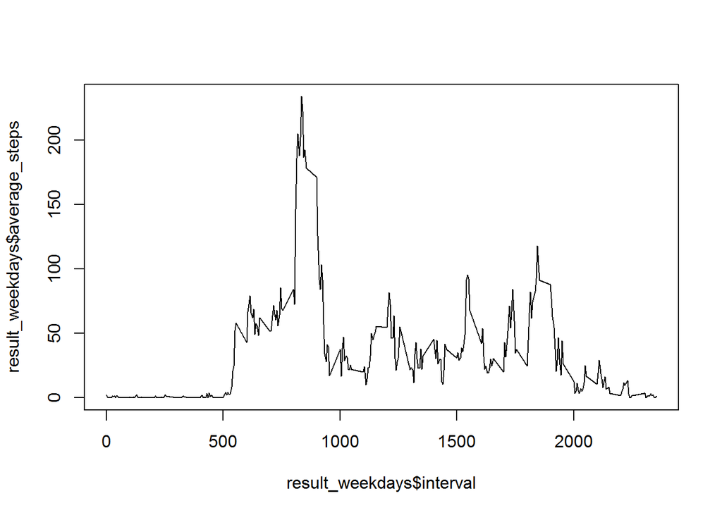

```r
day=weekdays(as.POSIXct(cleandata$date))
cleandata_day=cbind(cleandata,day) %>%
   mutate(day_type = ifelse(day=="Monday","weekday",
                       ifelse(day=="Tuesday","weekday",
                         ifelse(day=="Wednesday","weekday",
                           ifelse(day=="Thursday","weekday",
                             ifelse(day=="Friday","weekday", "weekend"))))))
weekdays=cleandata_day[which(cleandata_day[,5]=="weekday"),]
weekend=cleandata_day[which(cleandata_day[,5]=="weekend"),]
result_weekdays=weekdays %>%
   group_by(interval) %>%
   summarize(average_steps=mean(steps))
result_weekend=weekend %>%
   group_by(interval) %>%
   summarize(average_steps=mean(steps))
plot(result_weekdays$interval,result_weekdays$average_steps,type="l")
```

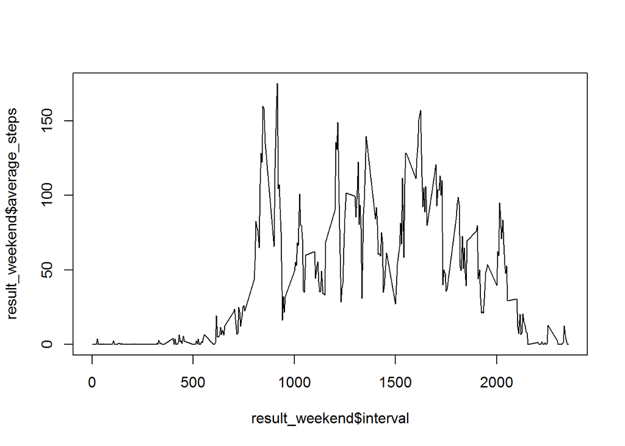

```r
plot(result_weekend$interval,result_weekend$average_steps,type="l")
```